# Live Session Question 2 CLT

Bivin

9/6/2018

# 1 Simulator to Demonstrate CLT

## 1.1 Control Parameters

From the Rmarkdown file in the Live Session 1 repository on Github, we create an R file by placing the extension *.r instead of the* .Rmd extension. From here, we can modify and debug the assignment.

### 1.1.1 UPDATE: After learning a bit more about R and Rmarkdown, the above paragraph was done out of ignorance.

Restated, the assignment is:  
1. *Adapt the code to generate a population of 10,000,000 from a chi-square distribution with 2 degrees of freedom. This is a heavily right skewed distribution. (Hint: rchisq()) You will have to read up on this function and probably do some trial and error. Being able to learn new functions and methods is a key skill.*

```r
#n1 is the number of Random values selected

n1 <- 10000000

#generate 10,000,000 random values that follow Chi-Square distribution with df=2 (degrees of freedom)

values <- rchisq(n1, df = 2) # right skewed chi square function.  first variable is the number of values and the second is the degrees of freedom.

#view first 5 values
head(values)
```

```
## [1] 8.0474455 0.1146077 0.1810189 1.7288719 0.3788308 7.9939221
```

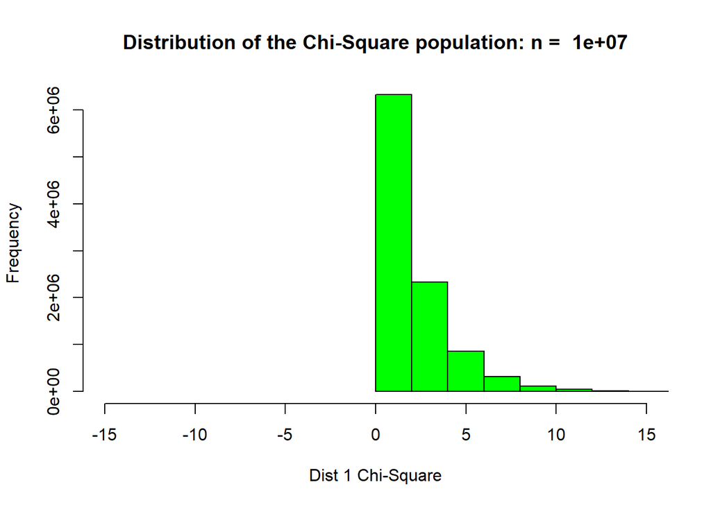

```r
#create a histogram to visualize distribution of values
hist(values, col = "green", main = paste("Distribution of the Chi-Square population: n = ", n1), xlab = "Dist 1 Chi-Square", xlim = c(-15,15))
```

```r
#Determine the mean and standard error of the values
x <- mean(values)
y <- sd(values)
paste("The mean of the population is,", x, "The standard deviation of the population is,", y)
```

```
## [1] "The mean of the population is, 1.99953330134234 The standard deviation of the population is, 1.99959039519548"
```

```r
z <- (x - y)

paste("The difference between the mean x and the standard deviation y is,", z)
```

```
## [1] "The difference between the mean x and the standard deviation y is, -5.70938531423426e-05"
```

#distribution of sample means of size 50 from this right skewed population?

#ANSWER: The means of the sample size 50 should be the same as the mean of the population: mux = mu(sample)

#What shoud be the mean and standard error of the mean (stand deviation of of the distribution of sample means)? #ANSWER: The standard error should be smaller by a facter of 1/squareroot(50)

#Part 5 is to run the math and check the CLT

##SECOND PART

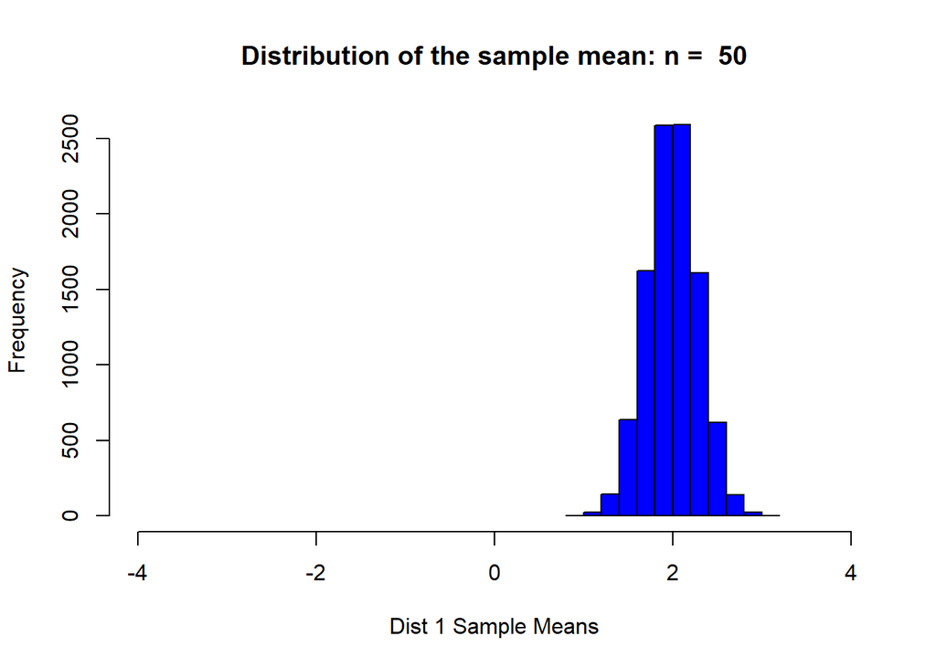

```r
n2 <- 50 # sample size per sample for 1st distribution
simulations <- 10000 #number of samples and thus number of xbars we will generate.
mu <- x # mean parameter for use with normal distributions, taken from the chi-square results above.
sigma <- y # standard deviation parameter for use with normal distributions, taken from the chi-square results above.

xbar_holder1 <- numeric(simulations) # This will hold all the sample means for the first distribution.

for (i in 1:simulations)
{
 sample1 <- rnorm(n2,mean = mu, sd = sigma) #To insure that the histogram functions properly, the mean of this sample1 is the mean of the 10,000,000 sample chi-square, above.  The standard deviation is likewise taken from above.

xbar1 <- mean(sample1)
xbar_holder1[i] <- xbar1
}

hist(xbar_holder1, col = "blue", main = paste("Distribution of the sample mean: n = ", n2), xlab = "Dist 1 Sample Means", xlim = c(-4,4))
```

```r
summary(xbar_holder1) #5 number summary and the mean
```

```
##    Min. 1st Qu.  Median    Mean 3rd Qu.    Max.
##  0.9379  1.8051  1.9982  1.9981  2.1890  3.0842
```

```r
sd(xbar_holder1) # standard deviation of dstribution 1
```

```
## [1] 0.2829419
```

```r
paste(summary(xbar_holder1))
```

```
## [1] "0.937917174016435" "1.80510072511812"  "1.99817170852816"
## [4] "1.99813205320099"  "2.18899830474273"  "3.08423455934079"
```

```r
paste(sd(xbar_holder1))
```

```
## [1] "0.28294186373421"
```